# Сегментация пользователей

Алексей Найденов

12 октября 2016 г

# 1 Загрузка данных

Загрузим данные, связанные с описанием товаров и категорий.

```r
products <- read.csv("products.csv", sep=';', encoding="UTF-8")
product.categories <- read.csv("product-categories.csv", sep=';', encoding="UTF-8")
categories <- read.csv("categories.csv", sep=';', encoding="UTF-8")
```

Загрузим данные, связанные с историей просмотров и заказов.

```r
purchases <- read.csv("purchases.csv", sep=';', encoding="UTF-8")
item.views <- read.csv("item-views.csv", sep=';', encoding="UTF-8")
category.views <- read.csv("category-views.csv", sep=';', encoding="UTF-8")
item.views$eventdate = as.Date(item.views$eventdate)
purchases$eventdate = as.Date(purchases$eventdate)
```

# 2 Сегментация пользователей

При составлении схемы сегментации потребителей обычно используют две группы переменных [Kotler, 2006](https://www.amazon.com/Marketing-Management-12th-Philip-Kotler/dp/0131457578):

- поведение;
- описательные характеристики.

Так же выделим отдельно сегментацию по целям/результатам. История просмотров и заказов. пользователей позволяет провести сегментацию пользователей на основе их поведения, их целей и результата посещения интернет магазина.

# 3 Уникальные пользователи

В данной работе будем рассматривать каждую уникальную сессиию как индивидуального пользователя, в предположении о том, что по истечении времени срока сессии вкусы и поведение пользователя могли измениться. Выберем всех уникальных пользователей из историй просмотров и заказов.

```r
visitors <- data.frame(
  externalsessionid = unique(
    c(purchases$externalsessionid,
      item.views$externalsessionid,
      category.views$externalsessionid)))
nrow(visitors)
```

```
## [1] 22881
```

В итоге, имеем 22881 пользователей, которые необходимо сегментировать.

# 4 Выделение переменных

## 4.1 Поведение

Выделим следующие переменные, соответствующие поведению пользователя:

- общее время сессии
- число посещений - число уникальных дней просмотров за все время сессии
- число просмотров - число уникальных просмотров за все время сессии
- частота просмотров - число просмотров за один день активности сессии
- частота посещения - число посещений за один день активности сессии
- число просмотренных продуктов
- среднее время просмотра продукта

```r
behavior <- visitors %>%
  left_join(item.views %>%
              group_by(externalsessionid) %>%
              summarise(period = sqrt(as.numeric(max(eventdate) - min(eventdate)) + 1),
                        mean.product.view.freq = sqrt(n() / period),
                        n.product.view.total = sqrt(n()),
                        n.login.days = length(unique(eventdate)),
                        mean.login.freq = n.login.days / period,
                        n.product.view.total = length(unique(product_id)),
                        mean.product.view.duration = mean(duration)
              ), by = "externalsessionid"
  )
```

Заметим, что некоторые переменные были модифицрованы, т.е. взято не само значение, а квадратные корень. Это позволяет более явно выделить сегменты, не нарушая интерпретируемость результатов.

## 4.2 Цель/результат посещения

Выделим следующие переменные, соответствующие целям и результатам посещения:

- число заказов
- общая сумма заказов
- средняя сумма заказа
- частота заказов
- время первого заказа с момента первого просмотра

Эти переменные характерны тем, что у некоторых пользователей отсутствуют значения - если пользователь не сделал ни одного заказа. Не нарушая логики, заполняем пропуски значением (кроме `времени первого заказа с начала просмотра`)

```r
outcome <- visitors %>%
  left_join(
    purchases %>%
      group_by(externalsessionid) %>%
      summarise(n.orders = length(unique(ordernumber)),
                sum.totalcents=sum(totalcents),
                fisrt.purchasedate = min(eventdate)),
    by="externalsessionid"
  ) %>%
  left_join(item.views %>%
              group_by(externalsessionid) %>%
              summarise(fisrt.eventdate = min(eventdate),# дата первого просмотра
                        period = sqrt(as.numeric(max(eventdate) - min(eventdate)) + 1) # число просмотренных продуктов
              ), by = "externalsessionid"
  ) %>%
  mutate(choose.time = ifelse(fisrt.purchasedate >= fisrt.eventdate,
                              fisrt.purchasedate - fisrt.eventdate,
                              0),
         n.orders = ifelse(!is.na(n.orders), n.orders, 0),
         sum.totalcents = ifelse(!is.na(sum.totalcents), sum.totalcents, 0),
         mean.check = ifelse(n.orders != 0,
                             sum.totalcents / n.orders,
                             0),
         mean.order.freq = ifelse(!is.na(n.orders), n.orders / period, 0))
```

## 4.3 Отбор независимых переменных

Соединим оба набора данных (по ключу `externalsessionid`) и уберем сильно кореллируемые переменные.

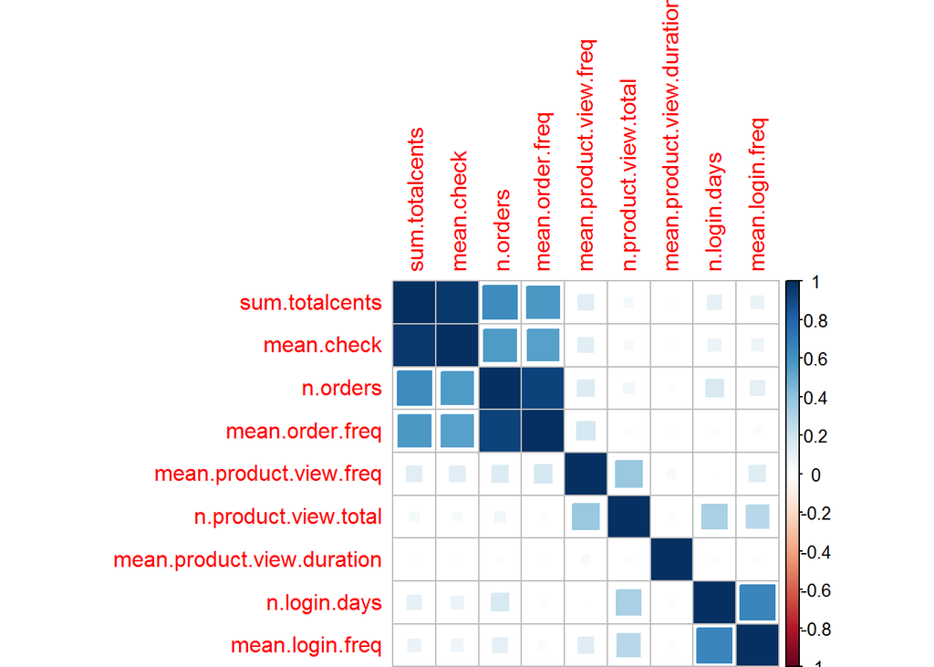

```r
correlations <- cor(outcome %>%
                      select(-period) %>%
                      left_join(behavior,
                                by="externalsessionid") %>%
                      select(-externalsessionid,-fisrt.purchasedate, -fisrt.eventdate, -choose.time, -period))
corrplot(correlations, method="square", order="hclust")
```

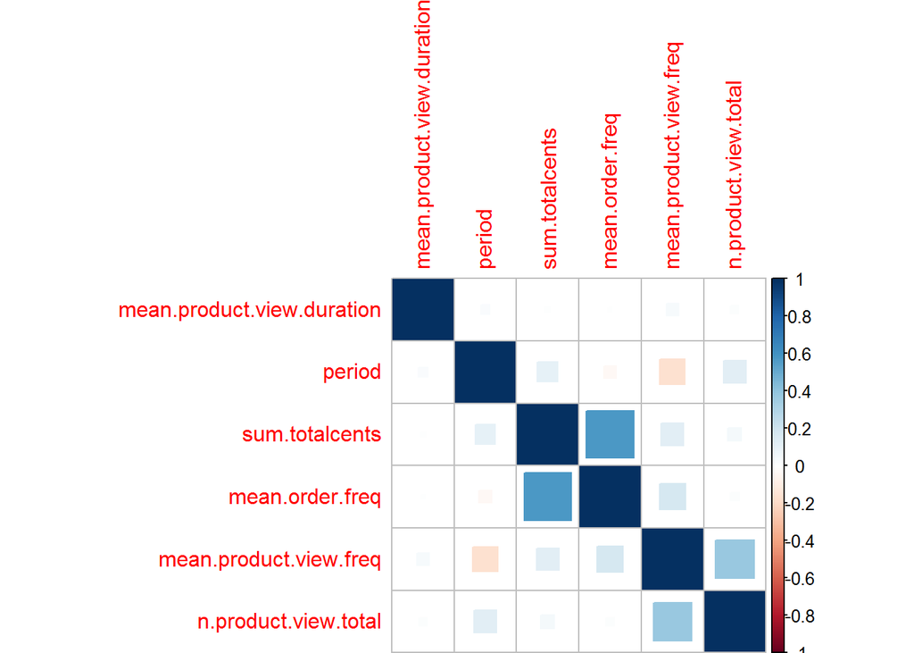

```r
data <- outcome %>%
  select(-period) %>%
  left_join(behavior,
            by="externalsessionid") %>%
  select(externalsessionid,
         mean.product.view.duration,
         period,
         mean.product.view.freq,
         n.product.view.total,
         sum.totalcents,
         mean.order.freq)
correlations <- cor(data %>%
                      select(-externalsessionid))
corrplot(correlations, method="square", order="hclust")
```

# 5 Кластеризация

```r
cluster2 <- kmeans(data %>%
                      select(-externalsessionid) %>%
                      apply(2, scale), 4, nstart = 20)
```